# Bootcamp 2023 - klasyfikacja

Author

KNUM ATLAS

```r
library(tidymodels)
library(tidyverse)

data("spam7", package = "DAAG")
df <- data.frame(spam7)
```

# Spam E-mail Data

## Opis

Dane składają się z 4601 wiadomości e-mail, z których 1813 zostało zidentyfikowanych jako spam. Jest to podzbiór pełnego zbioru danych, zawierający tylko sześć z 57 zmiennych objaśniających znajdujących się pełnym zbiorze danych.

https://rdrr.io/cran/DAAG/man/spam7.html

```r
head(df)
```

```
  crl.tot dollar  bang money n000 make yesno
1     278  0.000 0.778  0.00 0.00 0.00     y
2    1028  0.180 0.372  0.43 0.43 0.21     y
3    2259  0.184 0.276  0.06 1.16 0.06     y
4     191  0.000 0.137  0.00 0.00 0.00     y
5     191  0.000 0.135  0.00 0.00 0.00     y
6      54  0.000 0.000  0.00 0.00 0.00     y
```

Kolumny w naszym zadaniu:

- crl.tot - całkowita długość nieprzerwanych sekwencji wielkich liter
- dollar - wystąpienia znaku `$` jako procent wszystkich znaków
- bang - wystąpienia znaku `!` jako procent wszystkich znaków
- money - wystąpienia słowa `money` jako procent wszystkich słów
- n000 - wystąpienia ciągu `000` jako procent wszystkich słów
- make - wystąpienia słowa `make` jako procent wszystkich słów
- yesno - zmienna wynika określająca czy dana wiadomość była spamem

```r
str(df)
```

```
'data.frame':   4601 obs. of  7 variables:
 $ crl.tot: num  278 1028 2259 191 191 ...
 $ dollar : num  0 0.18 0.184 0 0 0 0.054 0 0.203 0.081 ...
 $ bang   : num  0.778 0.372 0.276 0.137 0.135 0 0.164 0 0.181 0.244 ...
 $ money  : num  0 0.43 0.06 0 0 0 0 0 0.15 0 ...
 $ n000   : num  0 0.43 1.16 0 0 0 0 0 0 0.19 ...
 $ make   : num  0 0.21 0.06 0 0 0 0 0 0.15 0.06 ...
 $ yesno  : Factor w/ 2 levels "n","y": 2 2 2 2 2 2 2 2 2 2 ...
```

```r
summary(df,digits = 1)
```

```
    crl.tot          dollar          bang          money            n000
 Min.   :    1   Min.   :0.00   Min.   : 0.0   Min.   : 0.00   Min.   :0.0
 1st Qu.:   35   1st Qu.:0.00   1st Qu.: 0.0   1st Qu.: 0.00   1st Qu.:0.0
 Median :   95   Median :0.00   Median : 0.0   Median : 0.00   Median :0.0
 Mean   :  283   Mean   :0.08   Mean   : 0.3   Mean   : 0.09   Mean   :0.1
 3rd Qu.:  266   3rd Qu.:0.05   3rd Qu.: 0.3   3rd Qu.: 0.00   3rd Qu.:0.0
 Max.   :15841   Max.   :6.00   Max.   :32.5   Max.   :12.50   Max.   :5.4
      make     yesno
 Min.   :0.0   n:2788
 1st Qu.:0.0   y:1813
 Median :0.0
 Mean   :0.1
 3rd Qu.:0.0
 Max.   :4.5
```

## Czyszczenie zbioru danych

Zmiana kolumny `yesno` w zmienną binarną, czyli tak aby zamiast `y` i `n` przyjomwała wartości `1` i `0` (dla wygody zmieniliśmy również nazwę na `spam`)

```r
colnames(df)[colnames(df) == 'yesno'] <- 'spam' #zmiana nazwy zmiennej
df$spam <- ifelse(df$spam == 'y', 1, 0) #zmiana wartośc w kolumnie na 1 i 0
```

```r
head(df)
```

```
  crl.tot dollar  bang money n000 make spam
1     278  0.000 0.778  0.00 0.00 0.00    1
2    1028  0.180 0.372  0.43 0.43 0.21    1
3    2259  0.184 0.276  0.06 1.16 0.06    1
4     191  0.000 0.137  0.00 0.00 0.00    1
5     191  0.000 0.135  0.00 0.00 0.00    1
6      54  0.000 0.000  0.00 0.00 0.00    1
```

```r
summary(df,digits = 1)
```

```
    crl.tot          dollar          bang          money            n000
 Min.   :    1   Min.   :0.00   Min.   : 0.0   Min.   : 0.00   Min.   :0.0
 1st Qu.:   35   1st Qu.:0.00   1st Qu.: 0.0   1st Qu.: 0.00   1st Qu.:0.0
 Median :   95   Median :0.00   Median : 0.0   Median : 0.00   Median :0.0
 Mean   :  283   Mean   :0.08   Mean   : 0.3   Mean   : 0.09   Mean   :0.1
 3rd Qu.:  266   3rd Qu.:0.05   3rd Qu.: 0.3   3rd Qu.: 0.00   3rd Qu.:0.0
 Max.   :15841   Max.   :6.00   Max.   :32.5   Max.   :12.50   Max.   :5.4
      make          spam
 Min.   :0.0   Min.   :0.0
 1st Qu.:0.0   1st Qu.:0.0
 Median :0.0   Median :0.0
 Mean   :0.1   Mean   :0.4
 3rd Qu.:0.0   3rd Qu.:1.0
 Max.   :4.5   Max.   :1.0
```

Bardzo wygodną (i dobrze wyglądającą) metodą do podsumowań tabelarycznych jest funkcja `stargazer` z pakietu o tej samej nazwie.

```r
library(stargazer)
stargazer(df, type = "text") #można korzystać też z innych formatów np. latex
```

```
=============================================
Statistic   N    Mean   St. Dev.  Min   Max
---------------------------------------------
crl.tot   4,601 283.289 606.348    1   15,841
dollar    4,601  0.076   0.246   0.000 6.003
bang      4,601  0.269   0.816   0.000 32.478
money     4,601  0.094   0.443   0.000 12.500
n000      4,601  0.102   0.350   0.000 5.450
make      4,601  0.105   0.305   0.000 4.540
spam      4,601  0.394   0.489     0     1
---------------------------------------------
```

Następnie możemy sprawdzić za pomocą macierzy korelacji jak mocno zmienne są ze sobą skorelowane

```r
library(rstatix)
corr <- cor_mat(df) #wyliczamy macierz korelacji
corr
```

```
# A tibble: 7 × 8
  rowname crl.tot dollar  bang money  n000  make  spam
* <chr>     <dbl>  <dbl> <dbl> <dbl> <dbl> <dbl> <dbl>
1 crl.tot   1       0.2  0.036 0.081 0.17  0.089  0.25
2 dollar    0.2     1    0.14  0.1   0.31  0.12   0.32
3 bang      0.036   0.14 1     0.051 0.07  0.058  0.24
4 money     0.081   0.1  0.051 1     0.053 0.19   0.22
5 n000      0.17    0.31 0.07  0.053 1     0.13   0.33
6 make      0.089   0.12 0.058 0.19  0.13  1      0.13
7 spam      0.25    0.32 0.24  0.22  0.33  0.13   1
```

```r
corr_pval <- cor_pmat(df) #obliczamy istotność korelacji
corr_pval
```

```
# A tibble: 7 × 8
  rowname  crl.tot    dollar     bang    money      n000     make      spam
  <chr>      <dbl>     <dbl>    <dbl>    <dbl>     <dbl>    <dbl>     <dbl>
1 crl.tot 0        1.52e- 43 1.37e- 2 3.77e- 8 8.91e- 30 1.37e- 9 4.62e- 66
2 dollar  1.52e-43 0         2.01e-22 1.09e-12 1.02e-103 1.35e-15 1.18e-112
3 bang    1.37e- 2 2.01e- 22 0        5.29e- 4 1.94e-  6 7.61e- 5 2.98e- 62
4 money   3.77e- 8 1.09e- 12 5.29e- 4 0        3.59e-  4 6.27e-38 9.30e- 50
5 n000    8.91e-30 1.02e-103 1.94e- 6 3.59e- 4 0         6.66e-20 6.73e-121
6 make    1.37e- 9 1.35e- 15 7.61e- 5 6.27e-38 6.66e- 20 0        8.49e- 18
7 spam    4.62e-66 1.18e-112 2.98e-62 9.30e-50 6.73e-121 8.49e-18 0
```

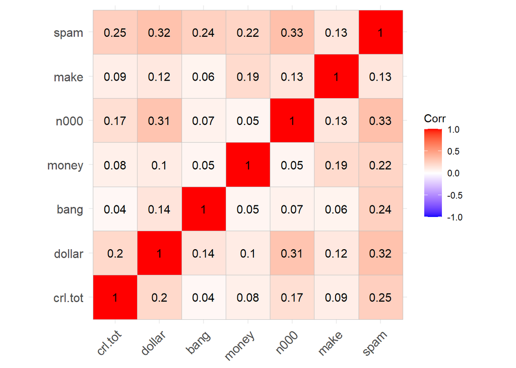

```r
library(ggcorrplot)
ggcorrplot(corr, p.mat=corr_pval, lab=T) #rysujemy wykres
```

Istotną kwestią jest sprawdzenie czy mamy do czynienia z zadaniem niezbalanoswanym, możemy to sprawdzić za pomocą zliczenia obserwacji (i metod graficznych)

Zamieniamy też zmienną wynikową na faktor żeby było łatwiej na niej dalej działać

```r
df$spam <- as_factor(df$spam)
```

```r
plyr::count(df, 'spam') #funkcja z biblioteki plyr to zliczenia obserwacji
```

```
  spam freq
1    0 2788
2    1 1813
```

Wykres możemy narysować korzystając z pakietu `ggplot2`

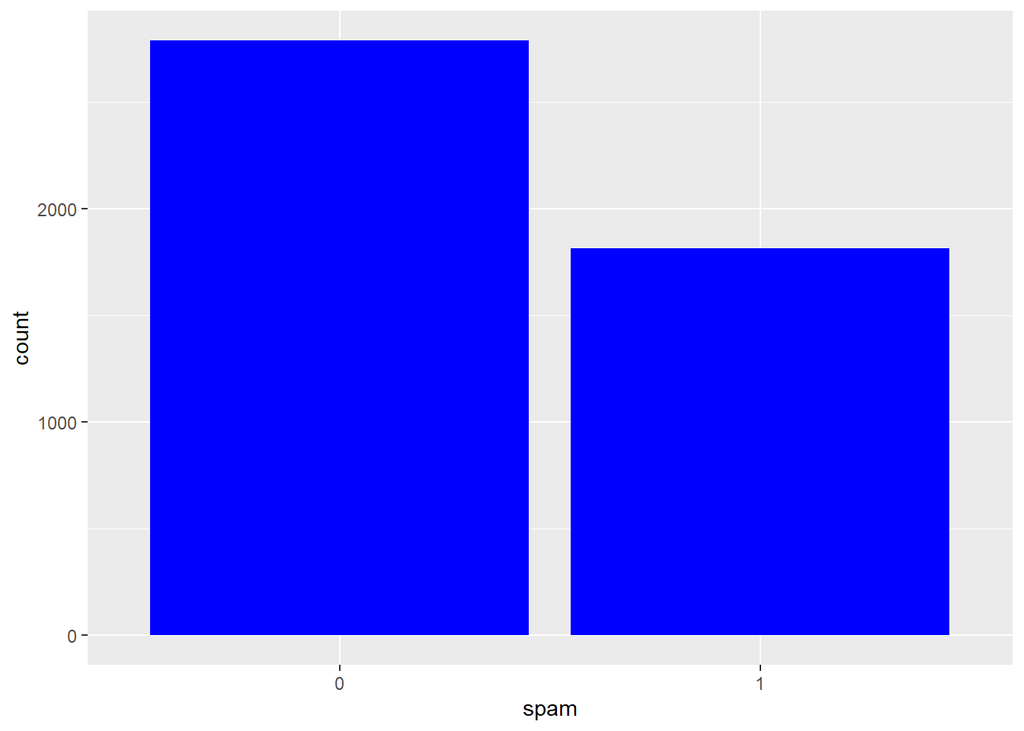

```r
ggplot(df,aes(x = spam)) +
  geom_bar(fill="blue")+
  xlab("spam")
```

Wykresy `ramka-wąsy` (*ang. `boxplot`*)

Możemy sprawdzić rozkład wartości poszczególnych zmiennych

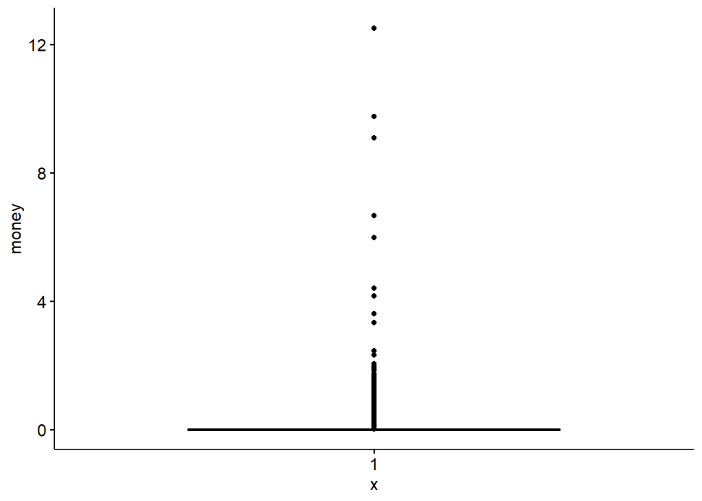

```r
library(ggpubr)
ggboxplot(df, y = "money")
```

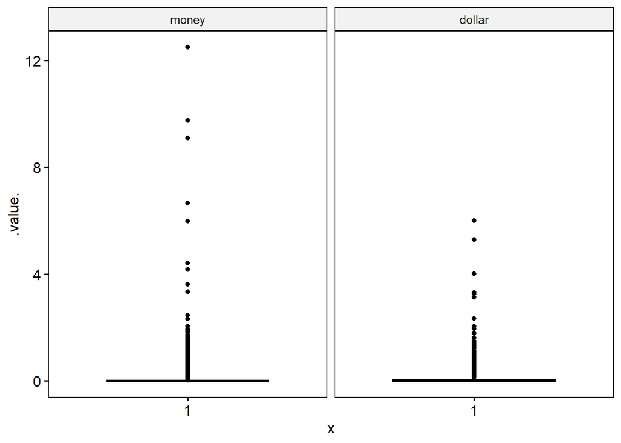

```r
ggboxplot(df, y = c("money", "dollar"), combine = T) #połączenie dwóch wykresów
```

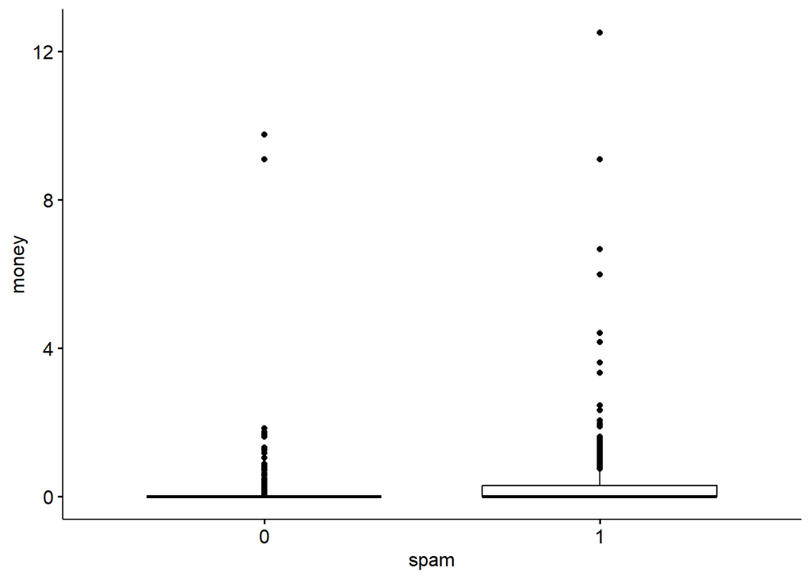

```r
ggboxplot(df, x = "spam", y="money") #rozkład zmiennej w podziale na spam
```

## Klasyfikacja

Zadanie to będzie wykonane w filozofii `tidymodels` (co możecie potraktować jako wstęp do pracy z tym pakietem)

### Podział zbioru

Po tym jak już przyjżeliśmy się naszym danym możemy przejść do procesu modelowania. Pierwszym etapem jest zawsze podział zbioru na uczący i testowy

```r
split <- initial_split(df,0.85, seed = 47) #funkcja tworząca podział
df_test <- testing(split) #tworznie zbioru testowego
df_train <- training(split) #tworzenie zbioru treningowego
```

```r
nrow(df_test)
```

```
[1] 691
```

```r
nrow(df_train)
```

```
[1] 3910
```

### Zdefiniowanie modeli

Następnie możemy zdefiniować modele które będziemy potem chcieli wykorzystać.

Model definiujemy za pomocą odpowaidającej mu funkcji podając:

- Rodzaj zadania - klasyfikacja lub regresja
- Silnik modelu
- Hiperparametry - jeżeli chcemy dostrajać model lub ustawić jakieś konkretne (można zostawić puste)

```r
#Model drzewa decyzyjnego
tree_mod <- decision_tree(mode = "classification",
                          engine = "rpart")

#Model drzewa z ustawionymi hiperparametrami
tree_mod2 <- decision_tree(mode = "classification",
                          engine = "rpart",
                          min_n = 20,
                          tree_depth = 7)

#Model regresji logistycznej
logreg_mod <- logistic_reg(mode = "classification",
                           engine = "glm")
```

### Tworzenie przepływu pracy

Można to porównać do tworzenia ‘pojemnika’ w którym będziemy trzymali nasz model i dodwali mu niezbędne rzeczy oraz prowadzili na nim wszystkie dalsze operacje np. uczenie.

```r
tree_wf <- workflow() %>% #tworzymy przepływ pracy
  add_model(tree_mod) %>% #dodajemy do niego model
  add_formula(spam~.) #dodajemy formułe
```

Dzięki `workflow` możemy w bardzo prosty sposób dodawać też preprocessing danych za pomocą ‘przepisów’. Przykładowo regresja logistyczna wymaga normalizacji predyktorów

```r
reg_rec <- recipe(spam~., data = df_train) %>% #definiujemy przepis podając formułę i zbiór danych
  step_normalize() #dodajemy krok normalizujący dane
```

```r
reg_wf <- workflow() %>%
  add_model(logreg_mod) %>% #dodajemy model
  add_recipe(reg_rec) #dodajemy wcześniej przygotowany przepis

#nie musimy dodwać formuły ponieważ podana została w przepisie
```

### Uczenie modelu

Przekazujemy przepływ pracy do funkcji `fit`

```r
tree_wf_fit <- tree_wf %>%
  fit(data = df_train)

reg_wf_fit <- reg_wf %>%
  fit(data = df_train)
```

```r
tree_wf_fit
```

```
══ Workflow [trained] ══════════════════════════════════════════════════════════
Preprocessor: Formula
Model: decision_tree()

── Preprocessor ────────────────────────────────────────────────────────────────
spam ~ .

── Model ───────────────────────────────────────────────────────────────────────
n= 3910

node), split, n, loss, yval, (yprob)
      * denotes terminal node

 1) root 3910 1525 0 (0.6099744 0.3900256)
   2) bang< 0.0795 2273  346 0 (0.8477783 0.1522217)
     4) dollar< 0.098 2093  213 0 (0.8982322 0.1017678) *
     5) dollar>=0.098 180   47 1 (0.2611111 0.7388889) *
   3) bang>=0.0795 1637  458 1 (0.2797801 0.7202199)
     6) dollar< 0.0065 851  424 1 (0.4982374 0.5017626)
      12) crl.tot< 77.5 433  131 0 (0.6974596 0.3025404)
        24) bang< 0.802 342   77 0 (0.7748538 0.2251462) *
        25) bang>=0.802 91   37 1 (0.4065934 0.5934066) *
      13) crl.tot>=77.5 418  122 1 (0.2918660 0.7081340) *
     7) dollar>=0.0065 786   34 1 (0.0432570 0.9567430) *
```

```r
reg_wf_fit
```

```
══ Workflow [trained] ══════════════════════════════════════════════════════════
Preprocessor: Recipe
Model: logistic_reg()

── Preprocessor ────────────────────────────────────────────────────────────────
1 Recipe Step

• step_normalize()

── Model ───────────────────────────────────────────────────────────────────────

Call:  stats::glm(formula = ..y ~ ., family = stats::binomial, data = data)

Coefficients:
(Intercept)      crl.tot       dollar         bang        money         n000
 -1.7243263    0.0007639    8.5108861    1.4852039    1.9678288    3.8498506
       make
  0.0608118

Degrees of Freedom: 3909 Total (i.e. Null);  3903 Residual
Null Deviance:      5230
Residual Deviance: 3438     AIC: 3452
```

### Predykcja i testowanie

```r
tree_pred <- predict(tree_wf_fit,df_test) #ramka danych z predykcją
head(tree_pred)
```

```
# A tibble: 6 × 1
  .pred_class
  <fct>
1 1
2 1
3 0
4 1
5 1
6 0
```

```r
reg_pred <- predict(reg_wf_fit,df_test) #ramka danych z predykcją
head(reg_pred)
```

```
# A tibble: 6 × 1
  .pred_class
  <fct>
1 0
2 1
3 0
4 1
5 1
6 0
```

Łączymy predykcje modelu i wartość rzeczywistą ze zbioru testowego w jedną ramkę

```r
tree_df <- bind_cols(tree_pred, 'target' = df_test$spam)
head(tree_df)
```

```
# A tibble: 6 × 2
  .pred_class target
  <fct>       <fct>
1 1           1
2 1           1
3 0           1
4 1           1
5 1           1
6 0           1
```

```r
reg_df <- bind_cols(reg_pred, 'target' = df_test$spam)
head(tree_df)
```

```
# A tibble: 6 × 2
  .pred_class target
  <fct>       <fct>
1 1           1
2 1           1
3 0           1
4 1           1
5 1           1
6 0           1
```

Dobrym podsumowaniem jakości modeli klasyfikacyjnych jest ‘Confusion Matrix’ czyli macierz pomyłek

```r
conf_tree <- conf_mat(tree_df, truth = "target", estimate = ".pred_class")
conf_tree
```

```
          Truth
Prediction   0   1
         0 344  66
         1  59 222
```

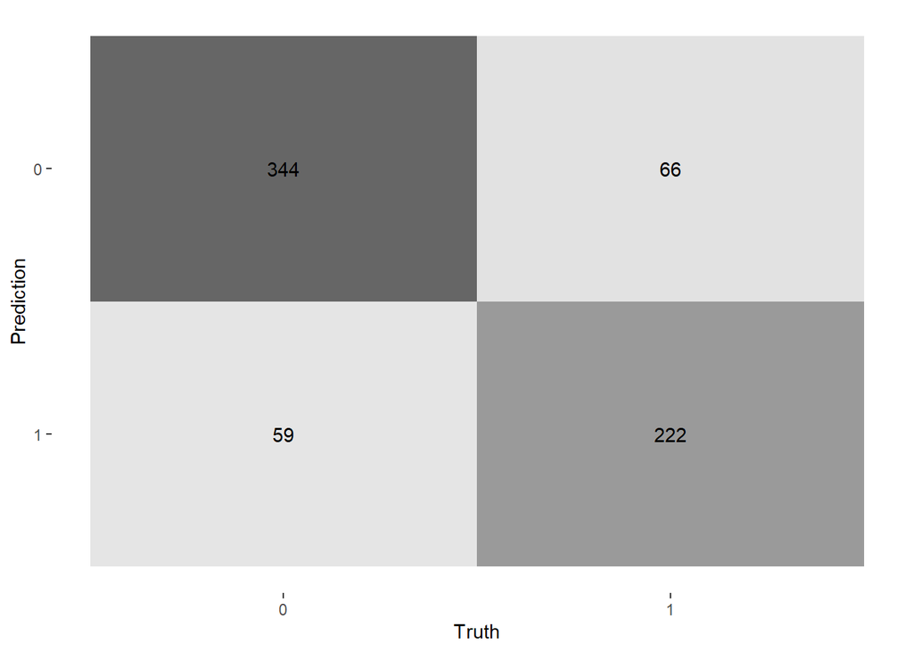

```r
autoplot(conf_tree, type = "heatmap")
```

```r
conf_reg <- conf_mat(reg_df, truth = "target", estimate = ".pred_class")
conf_reg
```

```
          Truth
Prediction   0   1
         0 382 109
         1  21 179
```

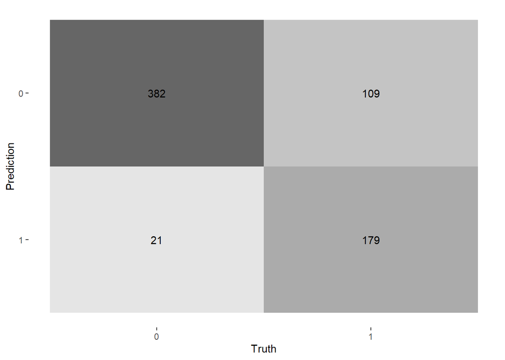

```r
autoplot(conf_reg, type = "heatmap")
```

Ewaluacja na wybranych metrykach możemy wyliczać przez odpowiednie funkcje

```r
accuracy(tree_df, truth = "target", estimate = ".pred_class")
```

```
# A tibble: 1 × 3
  .metric  .estimator .estimate
  <chr>    <chr>          <dbl>
1 accuracy binary         0.819
```

```r
sens(tree_df, truth = "target", estimate = ".pred_class")
```

```
# A tibble: 1 × 3
  .metric .estimator .estimate
  <chr>   <chr>          <dbl>
1 sens    binary         0.854
```

```r
j_index(tree_df, truth = "target", estimate = ".pred_class")
```

```
# A tibble: 1 × 3
  .metric .estimator .estimate
  <chr>   <chr>          <dbl>
1 j_index binary         0.624
```

W celu narysowania krzywej ROC i polieczenia ROC AUC potrzebujemy mieć predykcję w postaci prawdopodobieństw. Możemy je uzyskać tak samo jak wcześniej dodając arugment `type`

```r
tree_pred <- predict(tree_wf_fit,df_test, type = "prob") #ramka danych z predykcją
head(tree_pred)
```

```
# A tibble: 6 × 2
  .pred_0 .pred_1
    <dbl>   <dbl>
1  0.292    0.708
2  0.0433   0.957
3  0.775    0.225
4  0.261    0.739
5  0.0433   0.957
6  0.775    0.225
```

```r
reg_pred <- predict(reg_wf_fit,df_test, type = "prob") #ramka danych z predykcją
head(reg_pred)
```

```
# A tibble: 6 × 2
   .pred_0 .pred_1
     <dbl>   <dbl>
1 0.645      0.355
2 0.000608   0.999
3 0.764      0.236
4 0.298      0.702
5 0.0428     0.957
6 0.656      0.344
```

Łączymy predykcje modelu i wartość rzeczywistą ze zbioru testowego w jedną ramkę

```r
tree_df <- bind_cols(tree_pred, 'target' = df_test$spam)
head(tree_df)
```

```
# A tibble: 6 × 3
  .pred_0 .pred_1 target
    <dbl>   <dbl> <fct>
1  0.292    0.708 1
2  0.0433   0.957 1
3  0.775    0.225 1
4  0.261    0.739 1
5  0.0433   0.957 1
6  0.775    0.225 1
```

```r
reg_df <- bind_cols(reg_pred, 'target' = df_test$spam)
head(tree_df)
```

```
# A tibble: 6 × 3
  .pred_0 .pred_1 target
    <dbl>   <dbl> <fct>
1  0.292    0.708 1
2  0.0433   0.957 1
3  0.775    0.225 1
4  0.261    0.739 1
5  0.0433   0.957 1
6  0.775    0.225 1
```

```r
roc_auc(tree_df, truth = "target", ".pred_0")
```

```
# A tibble: 1 × 3
  .metric .estimator .estimate
  <chr>   <chr>          <dbl>
1 roc_auc binary         0.859
```

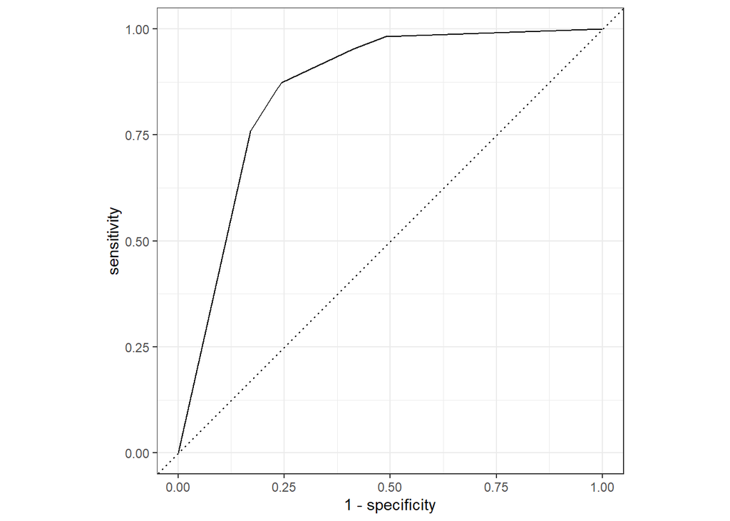

```r
roc_curve(tree_df, truth = "target", ".pred_0") %>%
  autoplot()
```

lub możemy narosować korzystając z pakietu `ggplot2`

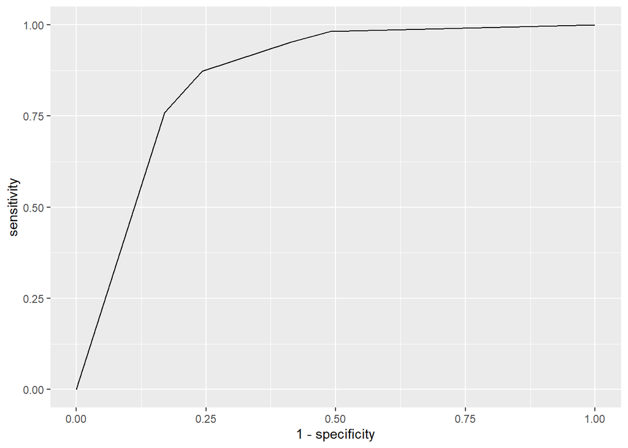

```r
tree_roc <- roc_curve(tree_df, truth = "target", ".pred_0")
ggplot()+
  geom_path(data=tree_roc,aes(x=1-specificity,y=sensitivity))
```

## Zapisywanie modelu

Jeżeli chcemy zapisać nasz wytrenowany model żeby użyć go np. w innym pliku możemy posłużyć się funkcją `saveRDS`

```r
saveRDS(tree_wf_fit, "tree_fit.rds")
```